# DS_Assignment4_HelenLin

Helen Lin (30776132)

2/15/2018

The Code: #Downloading data

library(tidyverse) source(“https://bioconductor.org/biocLite.R”) biocLite(“phyloseq”) library(phyloseq) load(“phyloseq_object.RData”)

#Dot plot without data

ggplot(metadata, aes(x=O2_uM, y=Depth_m))

#To add in the data, we must specify a geom

ggplot(metadata, aes(x=O2_uM, y=Depth_m)) + geom_point() #because when not specified within the geom, ggplot takes these data from the base ggplot function.

#Code down below is same as line 13

ggplot(metadata) + geom_point(aes(x=O2_uM, y=Depth_m))

#Can change colour

ggplot(metadata, aes(x=O2_uM, y=Depth_m, color=“blue”)) + geom_point()

#But this gives red - we need to put attributes in geom_point because it actually gives you the data points

ggplot(metadata, aes(x=O2_uM, y=Depth_m)) + geom_point(color=“blue”)

#Also applies to shapes and sizes

ggplot(metadata, aes(x=O2_uM, y=Depth_m)) + geom_point(shape=“square”)

ggplot(metadata, aes(x=O2_uM, y=Depth_m)) + geom_point(size=10)

#oxygen measurement in volts correlates with measurements in μM?

ggplot(metadata, aes(x=O2_uM, y=Depth_m, size=OxygenSBE_V)) + geom_point()

#Exercise 1 - plot NH4 against Depth (purple triangles)

ggplot(metadata, aes(x=NH4_uM, y=Depth_m)) + geom_point(shape=24, fill=“purple”, color=“purple”)

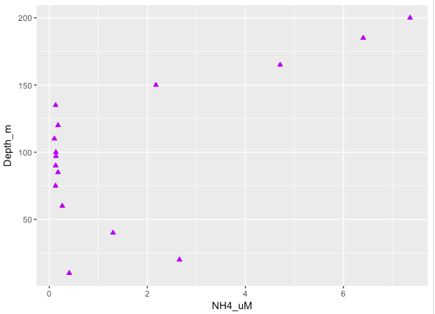

Exercise 1

#Exercise 2 - Celsius to Farenheit

metadata %>% mutate(Temperature_F = (Temperature_C*1.8)+32) %>% ggplot() + geom_point(aes(x=Temperature_F, y=Depth_m))

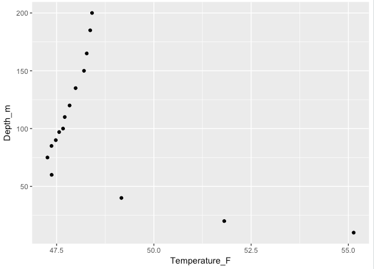

Exercise 2

#Phyloseq - alpha- and beta-diversity analyses as well as visualization of sequencing data physeq

#functions mirror ggplot like plot_bar = geom_bar.

#plot the phylum level communities by depth by simply specifying the fill.

plot_bar(physeq, fill=“Phylum”)

#Calculate percentage of total of each sample using transform_sample_counts

physeq_percent = transform_sample_counts(physeq, function(x) 100 * x/sum(x))

#Then plot the phyla, see 0-100% for all samples

plot_bar(physeq_percent, fill=“Phylum”)

#To remove separating lines and for R to no longer see OTUs as separate data by specifying stat as “identity”

plot_bar(physeq_percent, fill=“Phylum”) + geom_bar(aes(fill=Phylum), stat=“identity”)

#Exercise 3

plot_bar(physeq_percent, fill=“Domain”) + geom_bar(aes(fill=Domain), stat=“identity”) + labs(x = “Sample depth”, y = “Percent relative abundance”, title = “Domain from 10 to 200 m in Saanich Inlet”)

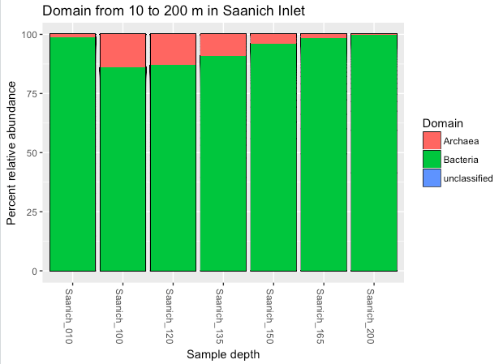

#Faceting - separate into multiple panels (or facets) to see patterns by adding “face_wrap” and tell it what variable to separate by

plot_bar(physeq_percent, fill=“Phylum”) + geom_bar(aes(fill=Phylum), stat=“identity”) + facet_wrap(~Phylum)

#Let R scale y-axes independently with “scales” parameter and remove legend in “theme”

plot_bar(physeq_percent, fill=“Phylum”) + geom_bar(aes(fill=Phylum), stat=“identity”) + facet_wrap(~Phylum, scales=“free_y”) + theme(legend.position=“none”)

#Exercise 4

metadata %>%  
gather(Nutrient, uM, NH4_uM, NO2_uM, NO3_uM, O2_uM, PO4_uM, SiO2_uM) %>%  
ggplot(aes(x=Depth_m, y=uM))+  
geom_point() +  
geom_line() +  
facet_wrap(~Nutrient, scales=“free_y”) + theme(legend.position=“none”)

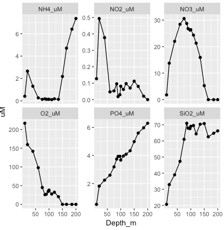